# Git and GitHub

Dr. Hua Zhou @ UCLA

Jan 12, 2021

## If it’s not in source control, it doesn’t exist.

[figure not shown]

## Collaborative research

Data scientists and statisticians, as opposed to closet mathematicians, rarely do things in vacuum.

- We talk to scientists/clients about their data and questions.
- We write code (a lot!) together with team members or coauthors.
- We run code/program on different platforms.
- We write manuscripts/reports with co-authors.
- We distribute software so potential users have access to your methods.

> In every project you have at least one other collaborator, **future-you**. You don’t want future-you to curse past-you.

> Hadley Wickham

## Why version control?

- A centralized repository helps coordinate multi-person projects.
- Time machine. Keep track of all the changes and revert back easily (reproducible).
- Storage efficiency.
- Synchronize files across multiple computers and platforms.
- [GitHub](https://github.com) is becoming a de facto central repository for open source development. E.g., all packages in Julia are distributed through GitHub; [Hadley Wickham](http://r-pkgs.had.co.nz) also recommends Git/GitHub as the best practices for R package development.
- **Advertise** yourself through GitHub.
- AmStat article: [What Is Data Science Specialization, and What Can It Do for You?](http://magazine.amstat.org/blog/2018/01/01/data-science-mooc/)

> What should an employer look for when they see a certification on a résumé?

> For our program, and likely data science in general, they should look at the applicant’s GitHub page. They should see interesting project and code contributions.

## Available version control tools

- Open source: Git, Apache subversion (aka svn), cvs, mercurial.
- Proprietary: Visual SourceSafe (VSS), etc.
- Dropbox? Mostly for file backup and sharing, limited version control (1 month?).

We use Git in this course.

## Git

- Currently the most popular version control system according to [Google Trend](https://trends.google.com/trends/explore?date=all&q=%2Fm%2F05vqwg,%2Fm%2F012ct9,%2Fm%2F08441_,%2Fm%2F08w6d6,%2Fm%2F09d6g&hl=en-US&tz=&tz=).
- Initially designed and developed by [Linus Torvalds](http://en.wikipedia.org/wiki/Linus_Torvalds) in 2005 for Linux kernel development. Git is the British English slang for unpleasant person.

> I’m an egotistical bastard, and I name all my projects after myself. First ‘Linux’, now ‘git’.

> Linus Torvalds

## Centralized vs distributed version control

Svn is a **centralized** version control system:

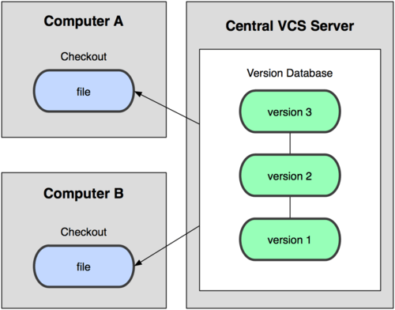

Git is a **distributed** version control system:

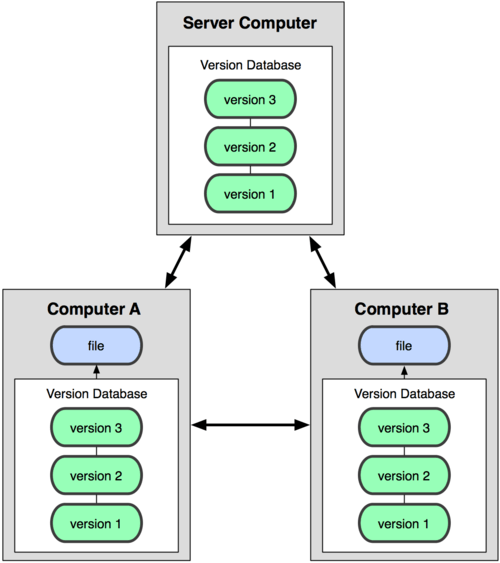

## What do I need to use Git?

- A **Git server** enabling multi-person collaboration through a centralized repository.
  - github.com: unlimited public repositories, private repositories costs $, but unlimited private repositories for free from [Student Developer Pack](https://education.github.com/pack).
  - bitbucket.org: unlimited public repositories, unlimited private repositories for academic account (register for free using your edu email).
  - We use github.com in this course for developing and submitting homework.
- A **Git client** on your own machine.
  - Linux: Git client program is shipped with many Linux distributions, e.g., Ubuntu and CentOS. If not, install using a package manager, e.g., `yum install git` on CentOS.
  - Mac: follow instructions at https://www.atlassian.com/git/tutorials/install-git.
  - Windows: [Git for Windows](https://gitforwindows.org) (GUI) aka Git Bash.
- RStudio supports Git.
- Do **not** totally rely on GUI or IDE. Learn to use Git on command line, which is needed for cluster and cloud computing.

## Git workflow

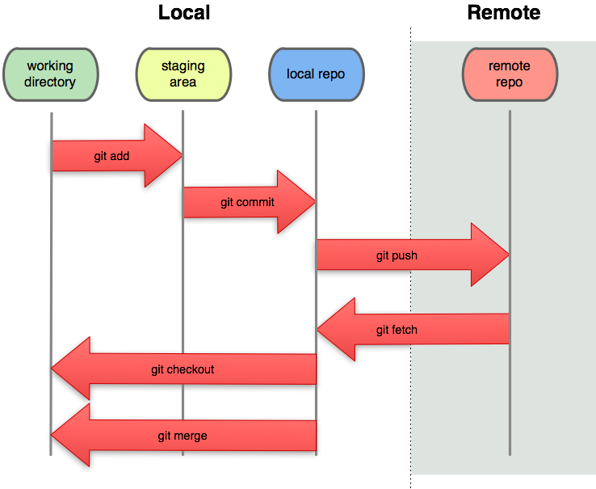

## Git survival commands

- Synchronize local Git directory with remote repository:

  ```bash
  git pull
  ```

  same as `git fetch` plus `git merge`.
- Modify files in local working directory.
- Add snapshots to staging area:

  ```bash
  git add FILES
  ```

- Commit: store snapshots permanently to (local) Git repository

  ```bash
  git commit -m "MESSAGE"
  ```

- Push commits to remote repository:

  ```bash
  git push
  ```

## Git basic usage

- Register for an account on a Git server, e.g., github.com.
- Upload your SSH public key to the server.
- Identify yourself at local machine, e.g.,

  ```bash
  git config --global user.name "Your Name"
  git config --global user.email "your_email@ucla.edu"
  ```

  Name and email appear in each commit you make.
- Initialize a project.
  - Create a repository, e.g., `biostat-203b-2021-winter` on GitHub.
  - Clone the repository to your local machine:

  ```bash
  git clone git@github.com:[USERNAME]/biostat-203b-2021-winter.git
  ```

## Branching in Git

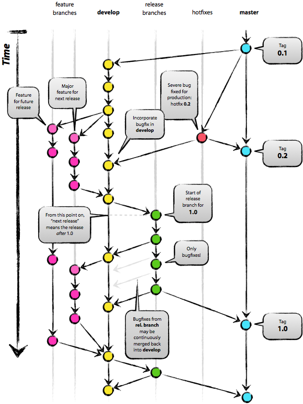

- For this course, you need to have two branches:
  - `develop` for your own development.
  - `master` for releases, i.e., homework submission.
  - Note `master` is the default branch when you initialize the project; create and switch to `develop` branch immediately after project initialization.

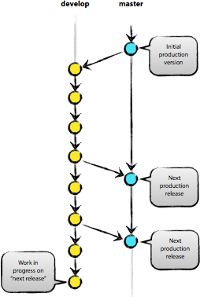

- Commonly used commands:
  - `git branch branchname`: create a branch.
  - `git branch`: show all project branches.
  - `git checkout branchname`: switch to a branch.
  - `git tag`: show tags (major landmarks).
  - `git tag tagname`: create a tag.

## Sample session | Getting started with homework | Lab 2

On [GitHub.com](https://github.com):

- Obtain [Student Developer Pack](https://education.github.com/pack).
- Create a private repository `biostat-203b-2021-winter`. Add `Hua-Zhou`, `Chris-German` and `ElvisHanCui` as your collaborators with write permission.

On your local machine:

- Clone the repository, create `develop` branch, where your work on solutions.

  ```bash
  # clone the project
  git clone git@github.com:biostat-203b-2021-winter.git
  # enter project folder
  cd biostat-203b-2021-winter
  # what branches are there?
  git branch
  # create develop branch
  git branch develop
  # switch to the develop branch
  git checkout develop
  # create folder for HW1
  mkdir hw1
  cd hw1
  # let's write solutions
  echo "sample solution" > hw1.Rmd
  echo "some bug" >> hw1.Rmd
  # commit the code
  git add hw1.Rmd
  git commit -m "start working on problem #1"
  # push to remote repo
  git push
  ```

- Submit and tag HW1 solution to master branch.

  ```bash
  # which branch are we in?
  git branch
  # change to the master branch
  git checkout master
  # merge develop branch to master branch
  # git pull origin develop
  git merge develop
  # push to the remote master branch
  git push
  # tag version hw1
  git tag hw1
  git push --tags
  ```

- RStudio has good Git integration. But practice command line operations also.

## Etiquettes of using Git

- Be judicious what to put in repository.
  - Not too less: Make sure collaborators or yourself can reproduce everything on other machines.
  - Not too much: No need to put all intermediate files in repository. Make good use of the `.gitignore` file.
  - Strictly version control system is for source files only. E.g. only `xxx.Rmd`, `xxx.bib`, and figure files are necessary to produce a pdf file. Pdf file doesn’t need to be version controlled or, if version controlled, doesn’t need to be frequently committed.
- Commit early, commit often and don’t spare the horses.
- Adding an informative message when you commit is not optional. Spending one minute on commit message saves hours later for your collaborators and yourself. Read the following sentence to yourself 3 times:

**Write every commit message like the next person who reads it is an axe-wielding maniac who knows where you live.**